# Validate Power: d2.1_m2fcfr

Kristin Porter, Zarni Htet, Kristen Hunter

December 20, 2021

Design: Blocked RCT, with 2 levels, and randomization done at level 1 (individual level).

Models: Constant treatment effects, fixed treatment effects, and random treatment effects.

Parameters by model type:

- Omega: $\omega_2 = 0$ for constant effects, $\omega_2$ = 0.1 for fixed and random
- ICC: $\text{ICC}_2 = 0$ for constant and fixed effects, $\text{ICC}_2$ = 0.2, 0.2, 0.2 for random effects

Assumptions:

- Two-level design: $\text{ICC}_3 = 0$, $\omega_3 = 0$, $K = 1$

# Power Validation

## Varying school size

$\bar{n}$ = 100

$\bar{n}$ = 75

## Varying R2

$R^2_1 =$ 0.6, 0.6, 0.6

$R^2_2 =$ 0.6, 0.6, 0.6

$R^2_1 =$ 0, 0, 0 $R^2_2 =$ 0, 0, 0

## Varying rho

$\rho =$ 0.2

$\rho =$ 0.8

## Varying true positives

ATE (ES) = 0.125, 0, 0

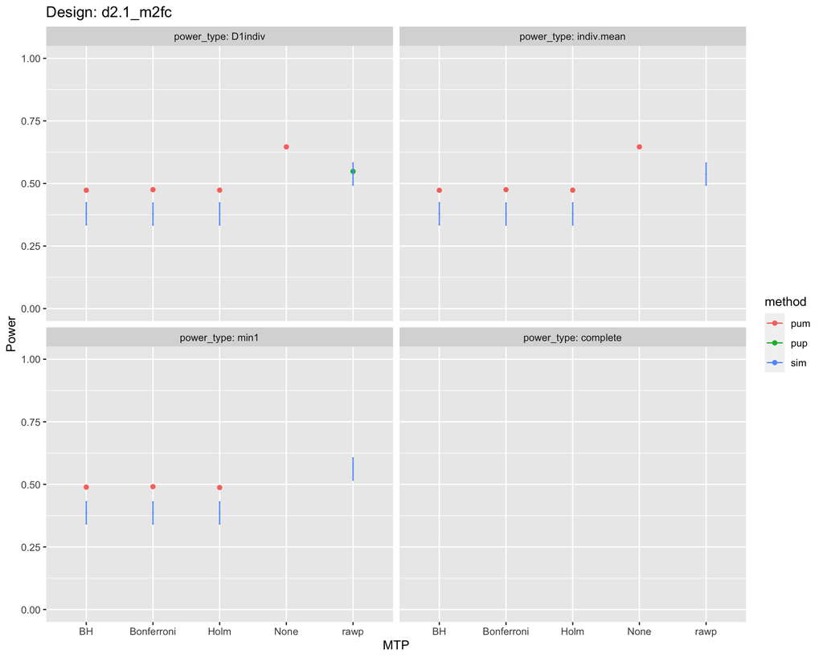

## Varying ICC

Note: we expect a discrepancy when ICC is not zero between powerup and pump.

$\text{ICC}_2$ = 0.7, 0.7, 0.7

$\text{ICC}_2$ = 0, 0, 0

## Varying Omega

$\omega_2$ = 0.8

$\omega_2$ = 0

## Kappa

$\kappa$ = 0.4